# 2012 Data RMD V3

Scott Stoner

2023

## Data Import

This section covers importing lake chemistry and watershed data for the purpose of lake selection. The relevant data is first retrieved from one of the NLS 2012 csv files. These variables fall into two categories, watershed and water chemistry. Additional variables are included to help with ID or shed light on connections made during PCA. Important to note that there are 2 ID systems in use, UIDs (unique sample event IDs) and Site IDs (lake specific IDs). Retaining both is important to select and summarize lakes with multiple sample events later in the process. Variable names and notes are included for each imported data set.

#### Site Info

- AREA_HA (lake area, hectares)
- STATE
- SIZE_CLASS
- SITETYPE (probability or handpicked)
- ELEVATION
- FS_EW (forest service land east or west)
- DSGN12 (incorporated in the NLA2012 design framework)
- NA_L2CODE (ecoregion level 2)
- NA_L3CODE (ecoregion level 3)
- URBAN (determination based on land use)
- EVAL_NAME (lake name)
- LAKE_ORIGIN (“manmade or natural”)
- PERIM_KM (lake perimeter)
- SITESAMP (was site sampled)
- DATE_COL (date of sample collection)
- SITE_ID (id code for site 2012 version)
- VISIT_NO (visit number for site)
- UID (unique site visit id)

```r
tb_import(c("UID", "SITE_ID", "VISIT_NO", "DATE_COL",
                 "SITETYPE", "SITESAMP", "DSGN12", "EVAL_NAME",
                 "STATE", "ELEVATION", "AREA_HA", "PERIM_KM",
                 "SIZE_CLASS", "FS_EW", "NA_L2CODE", "NA_L3CODE",
                 "URBAN", "LAKE_ORIGIN"), "nla2012_wide_siteinfo_08232016.csv") -> siteinfo
```

#### Watershed Data

- SITE_ID
- DOMGEOL_BSN (dominant geology)
- NLCD2006_ASSIGNEDAREA_BSN (area within basin assigned nlcd value*)
- NLCD2006_DEVELOPEDPCT_BSN (percent developed)
- NLCD2006_FORESTPCT_BSN (percent forest)
- NLCD2006_IMPERVAREA_BSN (percent impervious)
- PMEAN_BSN (mean annual precipitation in basin)[multiple precip values]
- TMEANPY_BSN (mean temperature in basin 12 months)[multiple temp values]

```r
tb_import(c("SITE_ID", "DOMGEOL_BSN", "NLCD2006_ASSIGNEDAREA_BSN", "NLCD2006_DEVELOPEDPCT_BSN", "NLCD2006_FORESTPCT_BSN", "NLCD2006_IMPERVAREA_BSN", "PMEAN_BSN", "TMEANPY_BSN"), "nla2012_wide_watershed.csv") -> watershed
```

#### Water Chemistry Data

- UID
- NTL_RESULT (Total Nitrogen mg/L)
- PTL_RESULT (Total Phosphorus ug/L)
- PH_RESULT

```r
tb_import(c("UID", "NTL_RESULT", "PTL_RESULT", "PH_RESULT"), "nla2012_waterchem_wide.csv") -> waterchem
```

## Data Merge and Initial Filter

The selected data from the imported tables is now combined into a single table that will be used for lake selection. First a left join using the SITE_ID field to append watershed data to general site info. Then a left join is used to append the water chemistry data to each visit using the UID field.

This table is then filtered to remove undesired lakes. First, lakes with no sampling data are excluded, followed by lakes that were not randomly selected, and third by visit number, removing duplicate visits.

```r
siteinfo %>%
  dplyr::left_join(watershed, by = "SITE_ID") %>%
  dplyr::left_join(waterchem, by = "UID") %>%
  dplyr::filter(SITESAMP == "Y") %>%
  dplyr::filter(SITETYPE == "PROB") %>%
  dplyr::filter(VISIT_NO == 1) -> initial_filter_result
```

## Lake Selection

Here is where the bulk of the lake selection process happens.

List of selection conditions in order:

1. NA_L2CODE = 6.2
- The 6.2 NA Ecoregion 2 Code represents the “Western Cordillera” also known as the Northwestern Forested Mountain Region.
2. STATE = CA, OR, WA, ID, MT
- The restriction to these 5 states removes areas of Ecoregion 6.2 that are mostly in Colorado and New Mexico.
3. Possibly more later: Elevation, Size, Land Use

```r
initial_filter_result %>%
  dplyr::filter(NA_L2CODE == 6.2) %>%
  dplyr::filter(STATE == "CA" | STATE == "OR" | STATE == "WA" | STATE == "ID" | STATE == "MT") -> watershed_filter_result
```

## Data Summary

These are summary statistics for the variables of interest.

```r
tb_summary(watershed_filter_result) %>%
  knitr::kable(format='simple', align='c')
```

|  | UID | VISIT_NO | ELEVATION | AREA_HA | PERIM_KM | NA_L2CODE | NLCD2006_ASSIGNEDAREA_BSN | NLCD2006_DEVELOPEDPCT_BSN | NLCD2006_FORESTPCT_BSN | NLCD2006_IMPERVAREA_BSN | PMEAN_BSN | TMEANPY_BSN | NTL_RESULT | PTL_RESULT | PH_RESULT |
| --- | --- | --- | --- | --- | --- | --- | --- | --- | --- | --- | --- | --- | --- | --- | --- |
|  | Min. : 6559 | Min. :1 | Min. : 108.1 | Min. : 1.033 | Min. : 0.4182 | Min. :6.2 | Min. : 0.070 | Min. : 0.0000 | Min. : 0.9744 | Min. : 0.00000 | Min. : 34253 | Min. : -50.37 | Min. :0.01400 | Min. : 4.00 | Min. :6.020 |
|  | 1st Qu.: 7259 | 1st Qu.:1 | 1st Qu.: 739.4 | 1st Qu.: 9.804 | 1st Qu.: 1.4034 | 1st Qu.:6.2 | 1st Qu.: 1.653 | 1st Qu.: 0.0000 | 1st Qu.:45.2671 | 1st Qu.: 0.00010 | 1st Qu.: 86633 | 1st Qu.: 391.80 | 1st Qu.:0.09525 | 1st Qu.: 10.62 | 1st Qu.:7.145 |
|  | Median : 7937 | Median :1 | Median :1398.7 | Median : 21.450 | Median : 2.3563 | Median :6.2 | Median : 7.803 | Median : 0.0000 | Median :65.8548 | Median : 0.01047 | Median :116180 | Median : 572.91 | Median :0.16800 | Median : 25.50 | Median :7.535 |
|  | Mean : 152965 | Mean :1 | Mean :1384.7 | Mean : 304.866 | Mean : 12.3257 | Mean :6.2 | Mean : 253.116 | Mean : 1.5864 | Mean :60.5675 | Mean : 2.04556 | Mean :127350 | Mean : 580.58 | Mean :0.30065 | Mean : 38.10 | Mean :7.573 |
|  | 3rd Qu.: 8478 | 3rd Qu.:1 | 3rd Qu.:1929.7 | 3rd Qu.: 119.981 | 3rd Qu.: 7.3028 | 3rd Qu.:6.2 | 3rd Qu.: 52.056 | 3rd Qu.: 0.8739 | 3rd Qu.:80.0400 | 3rd Qu.: 0.11035 | 3rd Qu.:156946 | 3rd Qu.: 724.75 | 3rd Qu.:0.32725 | 3rd Qu.: 47.75 | 3rd Qu.:7.938 |
|  | Max. :1000194 | Max. :1 | Max. :2732.8 | Max. :11052.354 | Max. :546.2851 | Max. :6.2 | Max. :15523.061 | Max. :58.3435 | Max. :96.6945 | Max. :99.43784 | Max. :324096 | Max. :1205.23 | Max. :2.61000 | Max. :288.00 | Max. :9.360 |

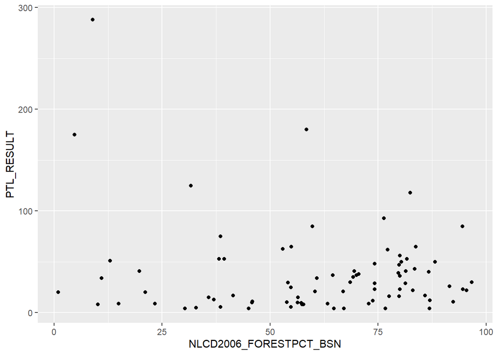

```r
tb_scatter(watershed_filter_result, NLCD2006_FORESTPCT_BSN, PTL_RESULT)
```

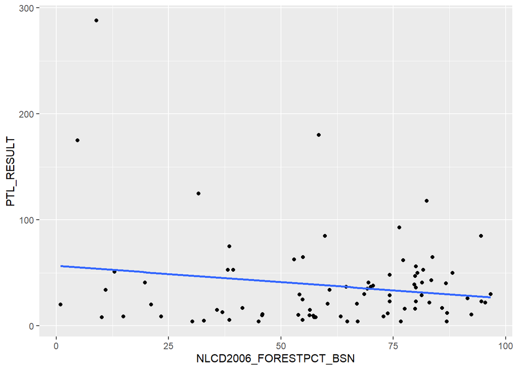

```r
tb_scatter_linreg(watershed_filter_result, NLCD2006_FORESTPCT_BSN, PTL_RESULT)
```

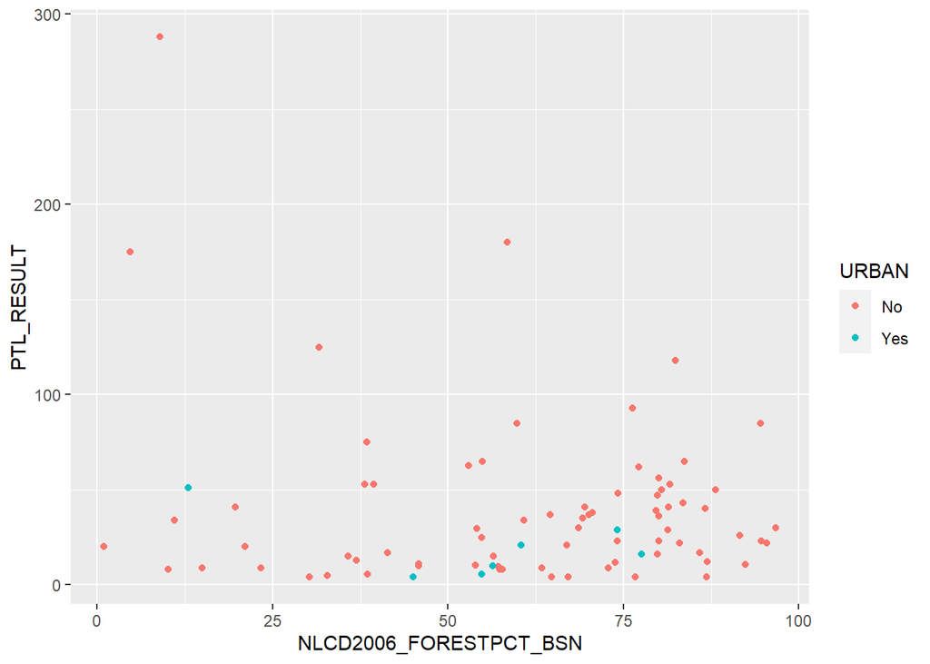

```r
tb_scatter_color(watershed_filter_result, NLCD2006_FORESTPCT_BSN, PTL_RESULT, URBAN)
```

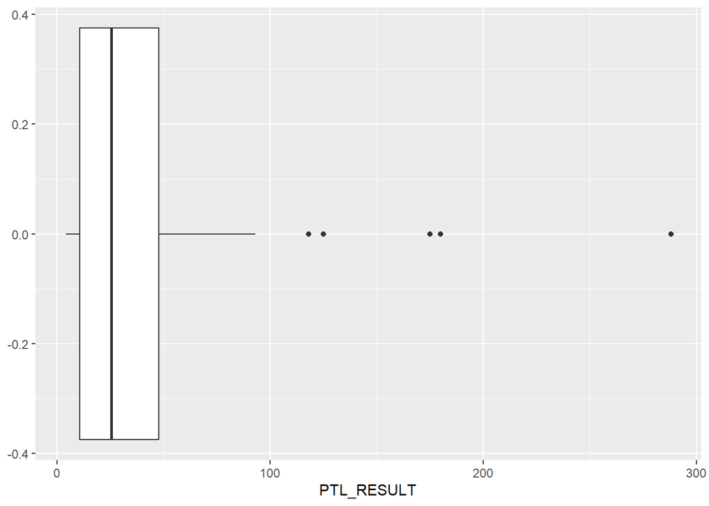

```r
tb_boxplot_single(watershed_filter_result, PTL_RESULT)
```

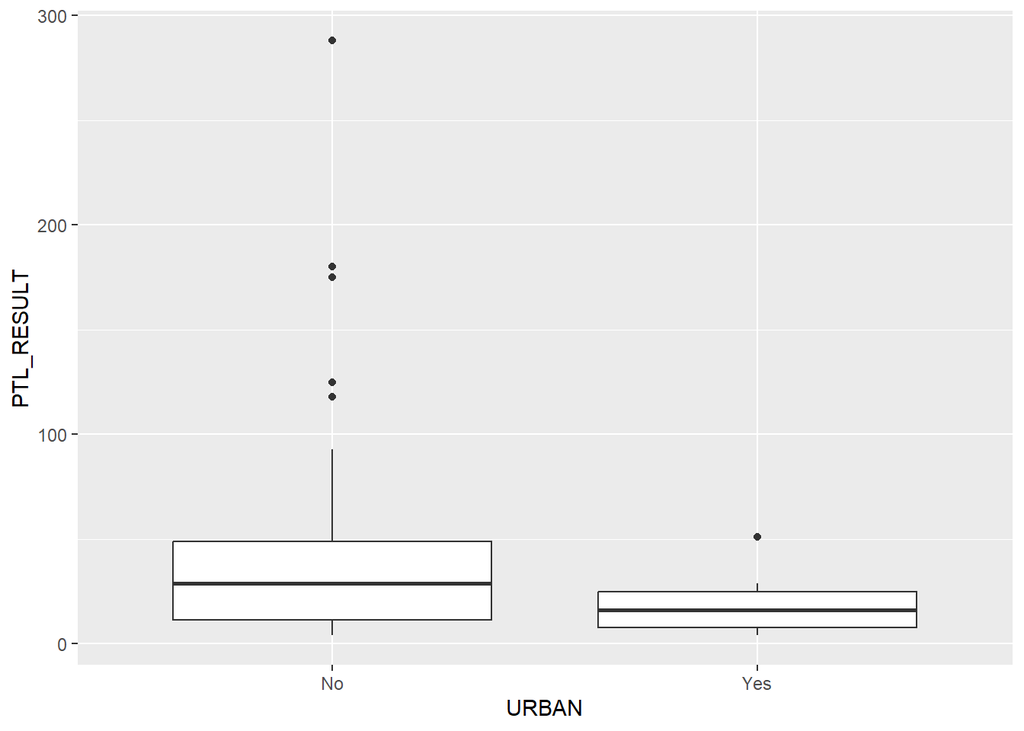

```r
tb_boxplot_multi(watershed_filter_result, URBAN, PTL_RESULT)
```

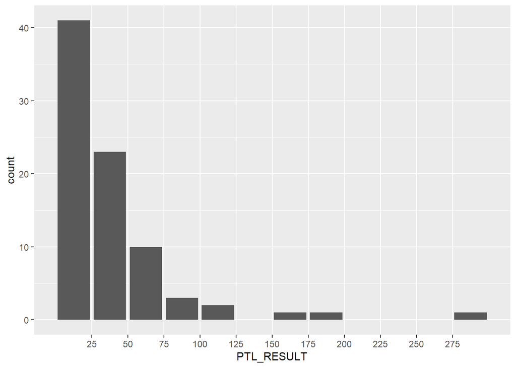

```r
tb_histogram(watershed_filter_result, PTL_RESULT)
```

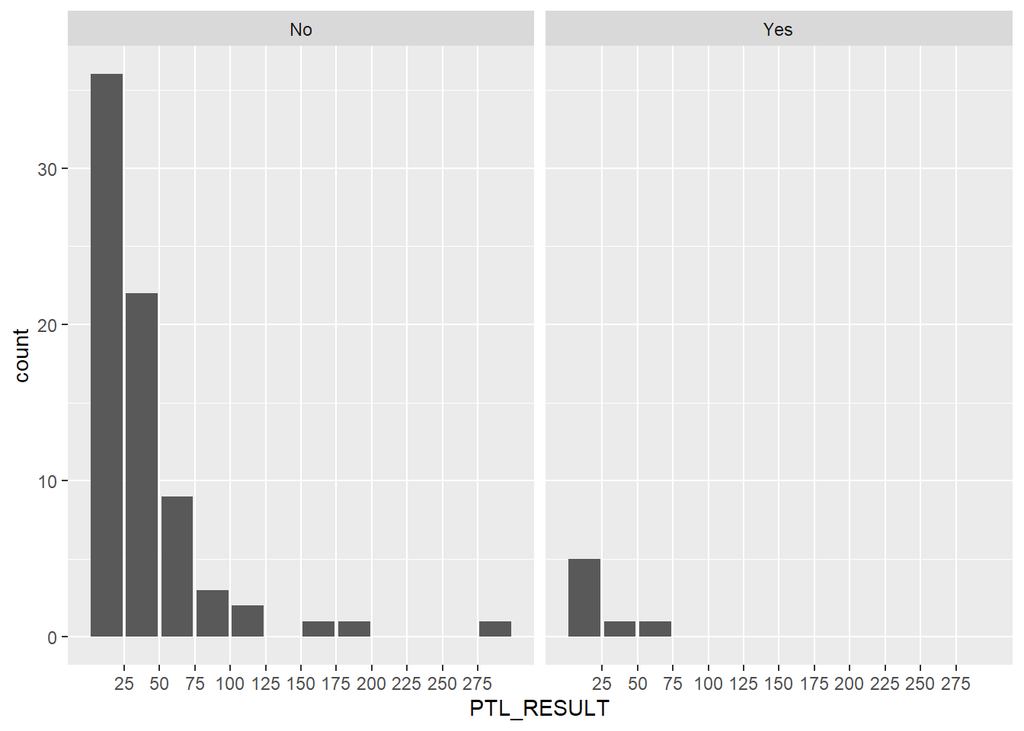

```r
tb_histogram_panel(watershed_filter_result, PTL_RESULT, URBAN)
```